# ANOVA Practice Solutions

`r`r library(tidyverse)

## 1. Training Program

First I’ll import the `TrainingProgram` dataset. I’ll `attach` it so its easy to refer to the columns, then I’ll look at the first few rows.

`r`r TrainingProgram <- read_csv(.csv)

`r`r attach(TrainingProgram)

`r`r head(TrainingProgram)

| Scores | Exam |
| --- | --- |
| 66 | A |
| 74 | A |
| 59 | B |
| 62 | B |
| 82 | A |
| 75 | A |

**Independence** The people were randomly assigned to two training programs, so the samples are independent.

**Normality** We can use boxplots to help us decide if the distributions seem approximately symmetric.

`r`r boxplot(Scores ~ Exam)

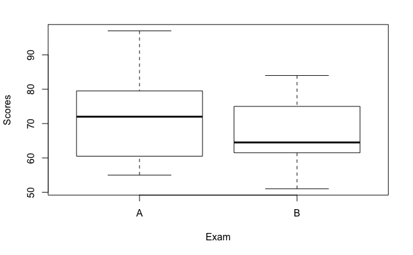

Both seem reasonably symmetric with no outliers, so we can assume they are approximately normal.

**Standard Deviations** remember the `tapply` command

`r`r tapply(Scores, Exam, sd)

```
        A         B
11.671725  9.099222
```

these are fine.

Now run the test.

`r`r myAnalysis <- aov(Scores ~ Exam) summary(myAnalysis)

```
            Df Sum Sq Mean Sq F value Pr(>F)
Exam         1    144   144.5   1.319   0.26
Residuals   30   3285   109.5
```

The p-value is rather large, so we do not have evidence that the mean scores are different in the two groups.

## Aisle location

Import the dataset, `attach` it, look at the first few rows.

`r`r AisleLocation <- read_csv(.csv)

`r`r attach(AisleLocation)

`r`r head(AisleLocation)

| Time | Location |
| --- | --- |
| 8.6 | Top |
| 7.2 | Top |
| 6.2 | Top |
| 5.4 | Top |
| 5.0 | Top |
| 4.0 | Top |

**Independence** Seems a reasonable assumption since subjects were assigned randomly.

**Normality** Let’s check boxplots.

`r`r boxplot(Time ~ Location)

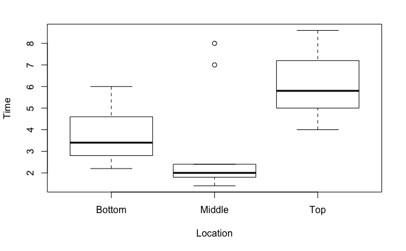

The `Middle` category does not look at all normal. It is not symmetric and has some outliers. I don’t think the normality assumption is met, so we cannot use the ANOVA test.

I would recommend we collect more data with more subjects if possible.

## New Packaging

Import the dataset, `attach` it, look at the first few rows.

`r`r Packaging <- read_csv(.csv)

`r`r attach(Packaging) head(Packaging)

| Rating | Design |
| --- | --- |
| 6.7 | New |
| 8.6 | New |
| 6.2 | New |
| 7.6 | New |
| 6.1 | New |
| 5.8 | New |

**Independence** Seems a reasonable assumption since subjects were assigned randomly.

**Normality** Let’s check boxplots.

`r`r boxplot(Rating ~ Design)

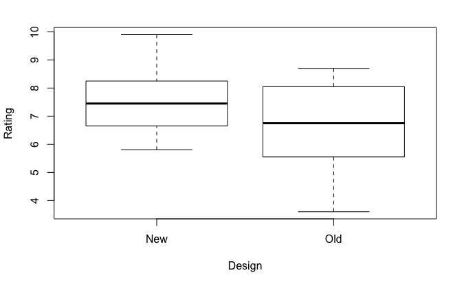

`Old` might have a slight skew, but both are reasonably symmetric, so we are ok with the normality assumption.

**Standard Deviations**

`r`r tapply(Rating, Design, sd)

```
     New      Old
1.157129 1.504686
```

These are fine.

Now run the test

`r`r packageAnalysis <- aov(Rating ~ Design) summary(packageAnalysis)

```
            Df Sum Sq Mean Sq F value Pr(>F)
Design       1   8.56   8.556   4.749 0.0356 *
Residuals   38  68.46   1.802
---
Signif. codes:  0 ‘***’ 0.001 ‘**’ 0.01 ‘*’ 0.05 ‘.’ 0.1 ‘ ’ 1
```

The p-value is less than 0.05, so we have some moderate evidence that there is a difference in the mean values between the two package designs.